# Question

La gráfica muestra parte de la información que recibe la familia **Díaz** en su **factura de energía eléctrica** del último mes.

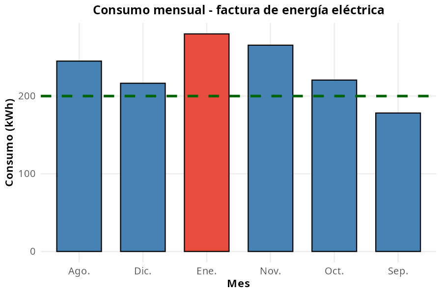

¿Cuál fue el consumo adicional en **kilovatios hora**?

## Answerlist

- 120 kWh
- 280 kWh
- 80 kWh
- 140 kWh

# Solution

Para resolver este problema, debemos calcular la diferencia entre el consumo del último mes y el plan contratado.

### Paso 1: Identificar los datos del problema

- **Consumo del último mes**: 280 kWh
- **Plan contratado**: 200 kWh

### Paso 2: Calcular el consumo adicional

El consumo adicional se calcula restando el plan del consumo total:

$$\text{Consumo adicional} = \text{Consumo último mes} - \text{Plan}$$

$$\text{Consumo adicional} = 280 - 200 = 80 \text{ kWh}$$

### Paso 3: Verificar el resultado

Como 280 > 200, efectivamente hay un consumo adicional de **80 kWh**.

**Por lo tanto, la respuesta correcta es: 80 kWh**

### Análisis de distractores

- **Incorrecto.** Esta opción sobreestima el consumo adicional. Resulta de un error en la escala de cálculo o en la operación matemática.
- **Incorrecto.** Esta opción corresponde al consumo total del último mes (280 kWh) sin restar el plan contratado. El consumo adicional es menor.
- **Correcto.** Esta opción corresponde a la diferencia exacta entre el consumo del último mes (280 kWh) y el plan contratado (200 kWh), es decir: 280 - 200 = 80 kWh.
- **Incorrecto.** Esta opción sobreestima el consumo adicional. Resulta de un error en la escala de cálculo o en la operación matemática.

## Answerlist

- Falso
- Falso
- Verdadero
- Falso

# Meta-information

exname: consumo_familiar_generico_interpretacion_n2 extype: schoice exsolution: 0010 exshuffle: TRUE exsection: Estadística/Interpretación de gráficos/Consumo familiar exextra[Type]: Interpretación y representación exextra[Level]: 2 exextra[Language]: es exextra[Course]: Matemáticas ICFES